# MATH-156 - Week 2 - Contingency Tables and Confounding Variables

**Directions**:

- As always, the expectation is that you thoughtfully work through this activity with a partner, discussing the embedded questions and recording your responses in a shared document
  - We will pause every 10ish minutes to go over certain questions as a class, you are expected to revise your write-up to update any responses that are inaccurate based upon these discussions
  - At times you will be asked to add screenshots to your write-up. If you are on a Windows PC, an easy way to do this is the “snipping tool”, which you can find using the search bar along the bottom of your screen. If you are on a Mac, you can find instructions on [how to take a screenshot at this link](https://support.apple.com/en-us/HT201361).
- Both you and your partner should upload your write-up to Canvas after class
  - Depending on our conversations you might not have time to finish all the questions in class - that’s okay and you don’t need to do them on your own. Your grade on these write-ups will be based upon whether you worked diligently during class. Accuracy will only count on one or two key questions (which will not be disclosed ahead of time, but will be early enough that you will have completed them if you were working at an appropriate pace)
- With that said, please do not try and rush through the questions, the purpose of these activities is to learn the material, not to hurriedly complete all the questions

$~$

## Introduction

This week our video lectures introduced the topic of *contingency tables*, which are used to express *associations* between two categorical variables. In today’s activity, we’ll look at two case studies involving contingency tables. In doing so, we’ll encounter a new challenge that we’ll need to figure out how to address.

$~$

## Case Study #1 - Death Penalty Sentencing in Florida

In the early 1980s, the *Harvard Law Review* [published a study](https://chicagounbound.uchicago.edu/cgi/viewcontent.cgi?article=12039&context=journal_articles) that analyzed data on murders that took place during a felony committed in the state of Florida between 1972 and 1977. The researchers were interested in whether the death penalty was being applied equally to both white and black offenders.

### Preliminary Steps

Before jumping into an analysis, we should be careful to understand the cases and variables in our data. You can use this link to access the [Florida Death Penalty Data](https://remiller1450.github.io/data/DeathPenaltySentencing.csv).

**Question #1**: What are the cases for these data? How many cases are there? What are the variables? Which variables are categorical or quantitative?

$~$

### Data Visualization

In our video lectures for this week, we learned about appropriate data visualizations that can help us understand the distributions of variables in our data. When comes to creating these graphs, we’ll use an online program known as [StatKey](https://www.lock5stat.com/StatKey/). In particular, we’ll use the “Descriptive Statistics and Graphs” section towards the top-left of the main screen.

To create a graph, first navigate to the proper spot for the variable(s) you want to display. Next, click the “Upload File” button and select the dataset (it’s most likely in your Downloads folder). Then, follow the directions on screen (select the column you’re interested in) to finish making your graph. Finally, notice that you will also get a summary table that reports descriptive statistics for the variable you chose.

**Question #2**: In our analysis of these data, the variables we will be primarily interested in are “OffenderRace” and “DeathPenalty”. Construct an appropriate univariate data visualization of each variable (ie: two separate graphs). Add a screenshot of your graphs to your write-up. Then, write one sentence describing what you believe to be the most important aspects of each variable’s distribution.

$~$

### Investigation

Now that we’ve got some insight into the variables we’ll be working with, it’s time to consider our research question: “Do the death penalty sentences in Florida from 1972-1977 show evidence of racial bias?”

**Question #3**: In our investigation, we’re hypothesizing that an *explanatory variable* leads to changes in a *response variable*. Identify these two variables in our data. Additionally, in this study, why wouldn’t it make sense to flip which is the explanatory and which is the response variable?

**Question #4**: Use the “Two Categorical Variables” menu on StatKey to create a contingency table and graphical display of these two variables. It is a convention among statisticians to use the explanatory variable as the row variable in the table (categorical variable #1 in StatKey), so please do this. Add a screenshot of your graph and table to your write-up.

**Question #5**: Use the “Proportions” options in StatKey to display the appropriate *conditional proportions* needed to answer the research question we posed earlier. In your write-up, include these proportions, as well as a sentence or two describing whether you think there is an association in these data.

**Question #6**: In Question #5, you chose to condition on either the row or column variable. Briefly explain why wouldn’t make sense to select the other option. That is, if you used row proportions, what’s the problem with column proportions? Or, if you used column proportions, what’s the problem with row proportions?

$~$

### Complications

Real-world phenomena are complex and can sometimes be difficult to reduce to an isolated comparison involving only two variables. In these data, you’ll notice that the researchers recorded a third variable, the race of the victim. In what follows, we’ll refine our prior analysis by taking this variable into consideration.

Shown below are the two-way frequency tables relating race of the offender and death penalty verdict after **stratifying** the data by the race of the victim.

Cases involving a White Victim

|  | Death | Not |
| --- | --- | --- |
| Black Offenders | 37 | 41 |
| White Offenders | 46 | 144 |

Cases involving a Black Victim

|  | Death | Not |
| --- | --- | --- |
| Black Offenders | 1 | 101 |
| White Offenders | 0 | 8 |

**Question #7**: Looking only at cases *involving a white victim*, are white or black offenders more likely to receive a death penalty sentence? Justify your answer using the appropriate conditional proportions.

**Question #8**: Looking only at cases *involving a black victim*, are white or black offenders more likely to receive a death penalty sentence? Justify your answer using the appropriate conditional proportions.

$~$

### Confounding Variables

A **confounding variable** is a third variable that is associated with both the explanatory and response variables. In this case study, race of the victim is a confounding variable. If a confounding variables exists within your data it can obscure the real relationship between the explanatory and response variables.

Sometimes the impact of the confounding variable is so substantial that it actually reserves the direction of association, as it did here. In the data as a whole, a greater proportion of white offenders received the death penalty. However, a greater proportion of black offenders received the death penalty when the victim was white and when the victim was black. This seemingly contradictory finding is an example of [Simpson’s Paradox](https://en.wikipedia.org/wiki/Simpson%27s_paradox).

Let’s try to understand the paradox by considering a few aspects of these data in greater detail.

**Question #9**: Considering no other variables, are offenders more likely to victimize someone of their own race or another race? Use two conditional proportions to justify your answer.

**Question #10**: Considering no other variables, were the Florida courts more likely to assign the death penalty when the case involved a white victim or a black victim? Use two proportions to justify your answer.

**Question #11**: Considering your answers to Questions #9 and #10, explain why there seemed to be little difference in death penalty sentencing rates overall, but a large discrepency after stratifying by the race of the victim?

$~$

## Case Study #2 - Grad School Admissions to UC-Berkeley

In 1973, an internal analysis of graduate student admissions into the University of California at Berkleley showed that men who applied appeared more likely to be admitted than women who applied. The difference was fairly substantial, and it garnered enough interest to cause the expert statisticians at UC-Berkeley to take a closer look at the data. In this case study, we’ll follow along with their analysis.

$~$

### Investigation

A contingency table summarizing the admissions data is shown below:

|  | Admitted | Rejected |
| --- | --- | --- |
| Males | 3714 | 4728 |
| Females | 1512 | 2809 |

**Question #12**: Using this contingency table, verify the claim that men were more likely to be admitted than women by calculating the appropriate conditional proportions.

$~$

### Confounding Variables?

A [research paper by Bickel et al.](https://homepage.stat.uiowa.edu/~mbognar/1030/Bickel-Berkeley.pdf) analyzed these data in greater detail, considering additional variables such as the particular department/program that each applicant applied to. Shown below is a summary of applicants to the six largest graduate departments at Berkeley:

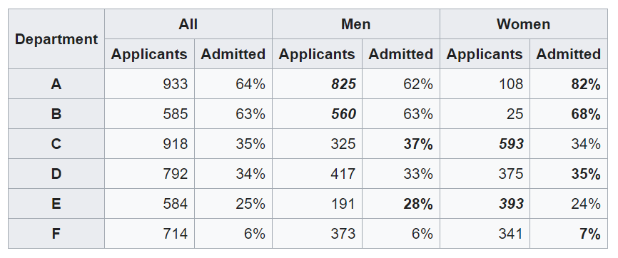

**Question #13**: Using the summary table provided above, does there appear to be a bias towards admitting males after the data are stratified by department?

**Question #14**: This is an example of Simpson’s Paradox (confounding). Can you explain why men have a much higher rate of admission overall, but tend to be admitted at lower rates in most departments?

$~$

### Closing Remarks

We will revisit what a data analyst can be do to address confounding variables in the coming weeks. For now, we’ve got **stratification** as one tool for neutralizing the effects of these problematic variables. As you may already recognize, a downside of stratification is that it reduces the number of cases that we have in each comparison. This is particularly troublesome if we identify multiple confounding variables. As we’ll soon see, it turns out that the experimental design tends to be a much more effect way of avoiding the impacts of confounding variables.

**Question #15** (Reflection): Write 2-3 sentences summarizing today’s activity. You can write about anything, but I encourage you to focus on something new that you learned, or something you still are wondering about in the realm of statistics/data analysis.